# STA141a Final report

Sihe Long

3/7/2022

# Abstract

We focus on the difference of COVID-19 situation in different countries or regions firstly. In this part, we used lots of different visualizations to show the result we get. We believe the visualizations can show the patterns of difference in a directly way. In the next part, we construct few models and pick a best one that could fit to our analysis. Then, with this model, we explore the relationship between infection situations and the total number of people who get vaccination. After that, with the help of a diagnosis test, we can find out the reliability of our analysis result. Finally, we get our conclusion have a comprehensive summary of our analysis report.

# Introduction

As we all know, in recent three years, the COVID-19 virus infection is a global disaster to our humans. Due to the reason that this virus has an extremely strong infectiousness, almost every country implied a series of policy to limit the infection. However, different countries or regions might have different policies due to different infection situation. So, firstly, in we are going to explore the difference of the COVID-19 situation among different countries or regions this project.

At the same time, we know that in last year(2021), our world has a new method to protect people from the COVID-19 virus, which is the vaccination. In this way, we are interested in a question that whether vaccination is an effective way to limit the infections. So,secondly, we will construct a model and fit the data in this model to see how the infection situation change when the total number of people who get vaccination increases. For this question, we will focus on the infection situation in the United States, since the US has one of the most effective vaccination around the world and we are American college students.

# Background

In this project, we firstly study a COVID-19 data set from World Health Organization(WHO). It gathered almost every country’s COVID-19 situation data(include new infected cases, cumulative infected cases, new death cases and cumulative death cases) daily, since the first day that COVID-19 began(January 3,2020). In this way, we believe it is one of the most credible datasets in the world. And therefore, we would use this data set to finish our descriptive analysis and try to answer our first question based on our rational result.

Then, we have another data set from a website called “Our World In Data” that is also updated daily. This data set is also credible, because it comes from the COVID-19 Data Repository by the Center for Systems Science and Engineering (CSSE) at Johns Hopkins University (JHU). We choose this data set to finish our inferential analysis because it includes the lots of vaccination data that not appeared in WHO data set. Since our second question is about vaccination, we rely on this data set in our second part.

# Descriptive analysis

```r
## Preprocessing ##
covid <- read_csv("https://covid19.who.int/WHO-COVID-19-global-data.csv")
covid_mutate <- covid %>%
  filter(WHO_region != "Other") %>%
  mutate(WHO_region = fct_recode(WHO_region,
                                 "Eastern Mediterranean"="EMRO","Europe" = "EURO","Africa" = "AFRO",
                                 "Western Pacific"="WPRO","Americas"="AMRO","South-East Asia" = "SEARO"))
```

Firstly, we are going to explore the difference of the COVID-19 situation among different regions

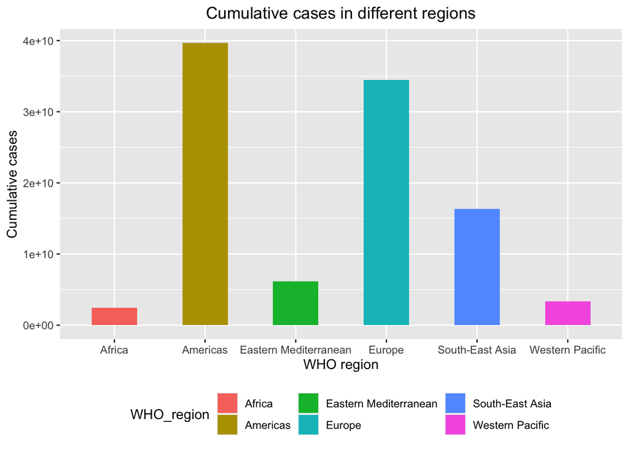

```r
#find out the cumulative cases difference in different regions
cum_case_diff_in_region <- ggplot(data=covid_mutate, mapping=aes(x=WHO_region, y=Cumulative_cases, fill=WHO_region)) +
  geom_bar(stat='identity', width=0.5) +
  theme(legend.position="bottom")+
  labs(title="Cumulative cases in different regions",x ="WHO region", y = "Cumulative cases")+
  theme(plot.title = element_text(hjust = 0.5))
cum_case_diff_in_region
```

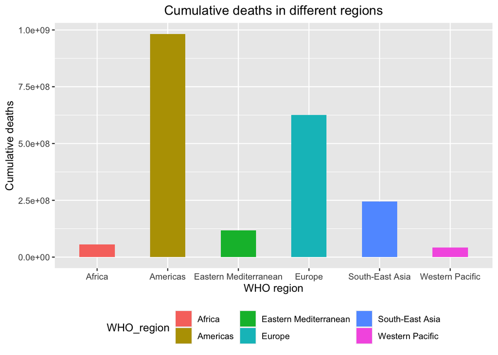

```r
#find out the cumulative death difference in different regions
cum_death_diff_in_region <- ggplot(data=covid_mutate, mapping=aes(x=WHO_region, y=Cumulative_deaths, fill=WHO_region)) +
  geom_bar(stat='identity', width=0.5) +
  theme(legend.position="bottom")+
  labs(title="Cumulative deaths in different regions",x ="WHO region", y = "Cumulative deaths")+
  theme(plot.title = element_text(hjust = 0.5))
cum_death_diff_in_region
```

From the plot above, we can see that the region of Americas has the most cumulative cases and cumulative deaths. Also, compare to other regions, the region of Europe has a large amount of cumulative cases and cumulative deaths. On the contrary，the region of Africa has the least cumulative cases and the region of Western Pacific has the least cumulative deaths.

Then, we are going to explore the difference of the latest COVID-19 situation among different regions, so we are going to pick the data of the latest week that was updated from WHO.

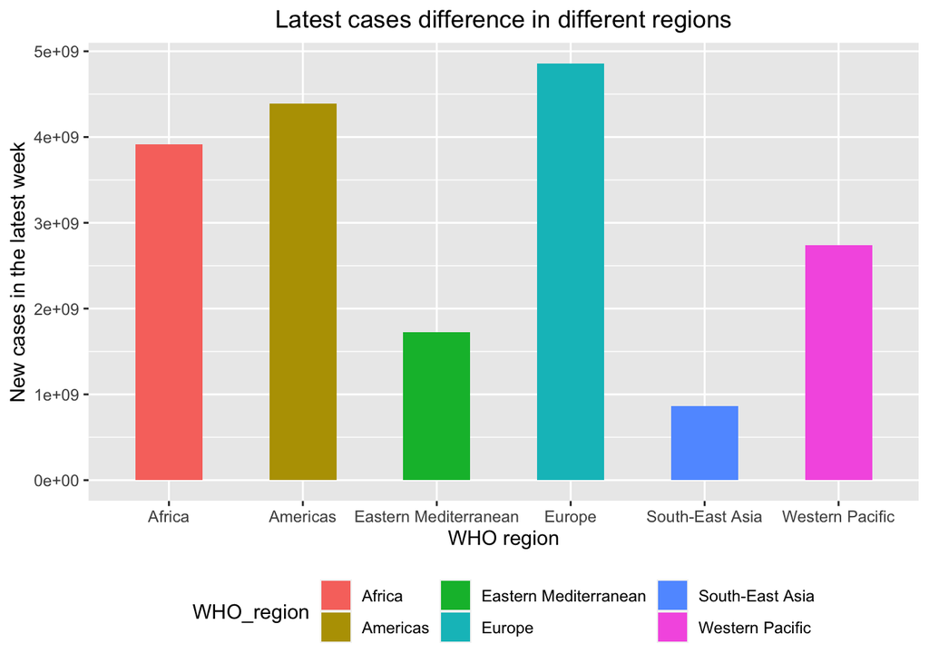

```r
covid_latest <- filter(covid_mutate, Date_reported >= '2022-03-06' & Date_reported <= '2022-03-12')#find the data of the latest week

#find out the latest new cases difference in different regions
latest_case_diff_in_region <- ggplot(data=covid_latest, mapping=aes(x=WHO_region, y=sum(New_cases), fill=WHO_region)) +
  geom_bar(stat='identity', width=0.5) +
  theme(legend.position="bottom") +
  labs(title="Latest cases difference in different regions",x ="WHO region", y = "New cases in the latest week") +
  theme(plot.title = element_text(hjust = 0.5))
latest_case_diff_in_region
```

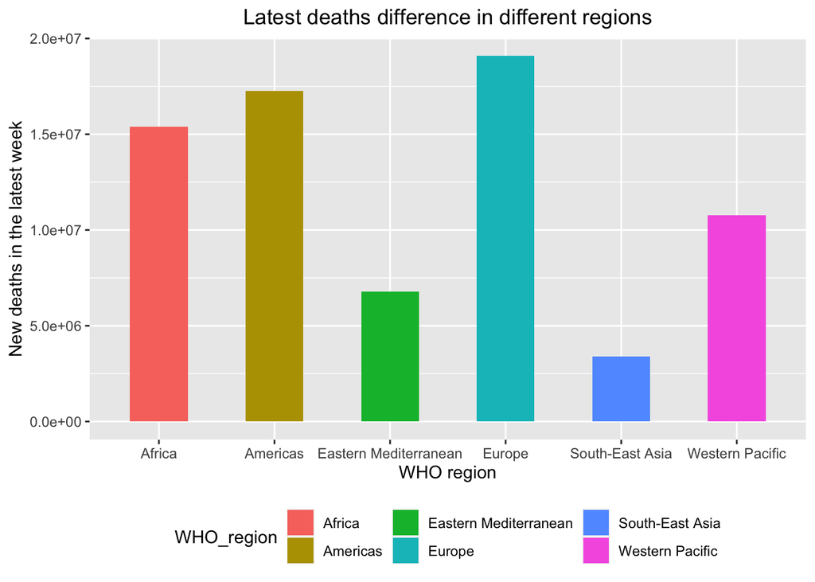

```r
#find out the latest new death difference in different regions
latest_death_diff_in_region <- ggplot(data=covid_latest, mapping=aes(x=WHO_region, y=sum(New_deaths), fill=WHO_region)) +
  geom_bar(stat='identity', width=0.5) +
  theme(legend.position="bottom") +
  labs(title="Latest deaths difference in different regions",x ="WHO region", y = "New deaths in the latest week") +
  theme(plot.title = element_text(hjust = 0.5))
latest_death_diff_in_region
```

After that, we are going to explore the daily cases/deaths trend of American region and United States of America from some visualization.

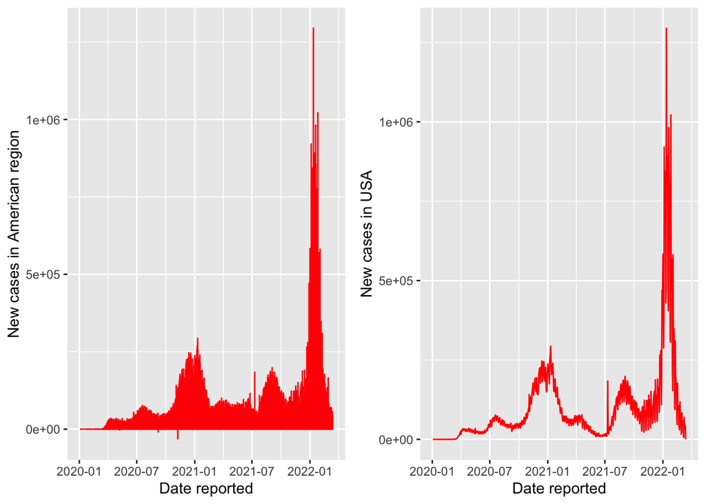

```r
# find out the data from American region
covid_americas_region <- covid_mutate %>% filter(WHO_region == 'Americas')

## daily case trend plot
Americas_daily_case <- covid_americas_region %>%
  ggplot(aes(x=Date_reported,y=New_cases)) +
  geom_line(color = "red", size = 0.5) +
  xlab("Date reported")+ylab("New cases in American region")

Americas_daily_death <- covid_americas_region %>%
  ggplot(aes(x=Date_reported,y=New_deaths)) +
  geom_line(color = "blue", size = 0.5) +
  xlab("Date reported")+ylab("New deaths in American region")

# find out the data from United States of America
covid_USA <- covid_mutate %>% filter(Country == 'United States of America')

## daily case trend plot
USA_daily_case <- covid_USA %>%
  ggplot(aes(x=Date_reported,y=New_cases)) +
  geom_line(color = "red", size = 0.5) +
  xlab("Date reported")+ylab("New cases in USA")

USA_daily_death <- covid_USA %>%
  ggplot(aes(x=Date_reported,y=New_deaths)) +
  geom_line(color = "blue", size = 0.5) +
  xlab("Date reported")+ylab("New deaths in USA")

gridExtra::grid.arrange(Americas_daily_case, USA_daily_case, nrow=1, ncol=2)
```

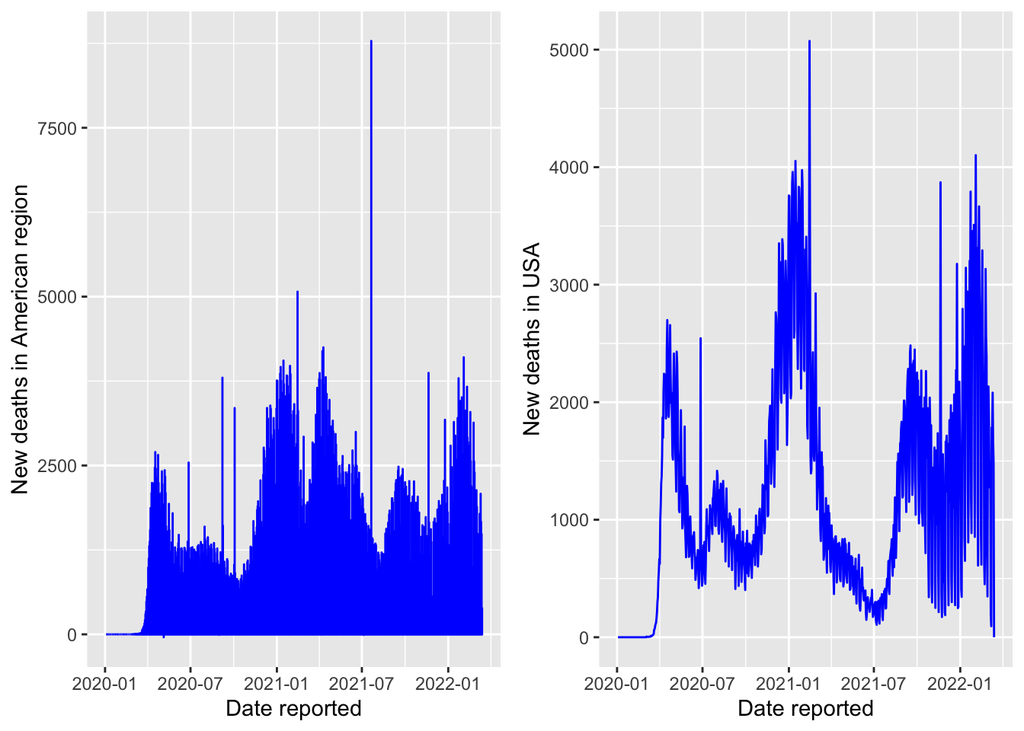

```r
gridExtra::grid.arrange(Americas_daily_death, USA_daily_death, nrow=1, ncol=2)
```

From the plot above, we can see that for American regions and United States of America, their trend plot of daily new cases has a similar pattern. Both of them have a relative peak at January in 2021, and an absolute peak at January in 2022. Luckily, the absolute peak is already passed and the daily new cases are not so much at present. While for American regions and United States of America, their trend plot of daily new deaths has a similar pattern also. Both of them have few relative peaks in last 2 yeas at the same time.

After that, we are going to explore the death rate(case-death rate) in United States of America in last 3 years

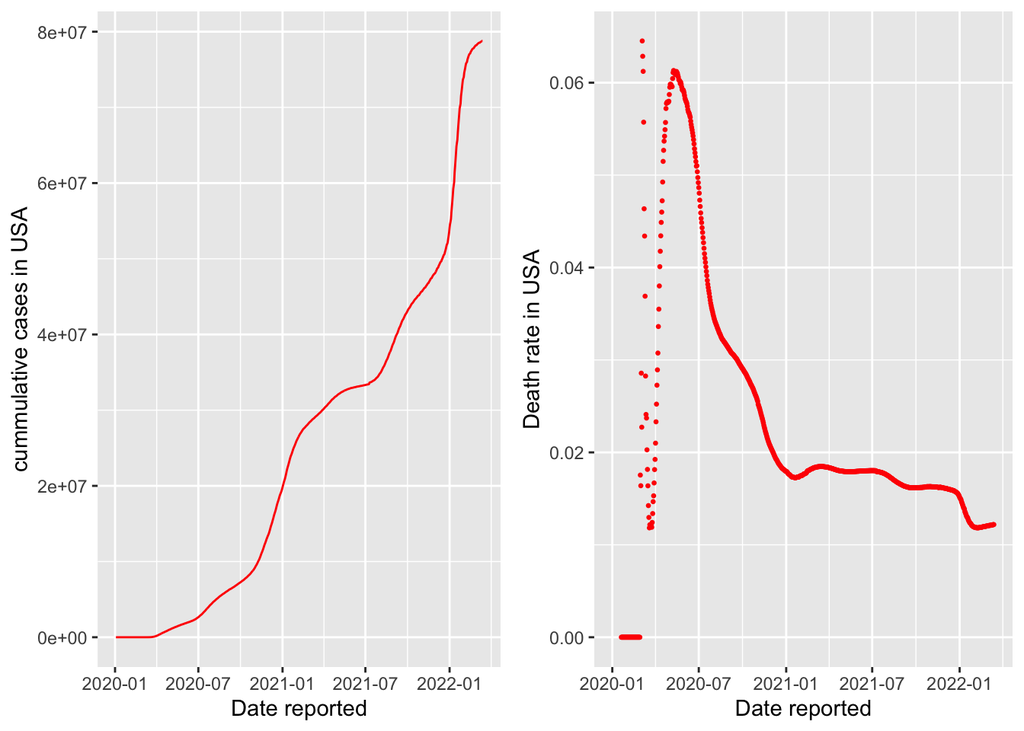

```r
## USA cumulative cases trend plot
USA_cum_case <- covid_USA %>%
  ggplot(aes(x=Date_reported,y=Cumulative_cases)) +
  geom_line(color = "red", size = 0.5) +
  xlab("Date reported")+ylab("cummulative cases in USA")

# find out the mortality rate(death-case rate) from United States of America
death_rate <- covid_USA$Cumulative_deaths/covid_USA$Cumulative_cases
USA_death_rate <- covid_USA %>%
  ggplot(aes(x=Date_reported,y=death_rate)) +
  geom_point(color = "red", size = 0.5) +
  xlab("Date reported")+ylab("Death rate in USA")

gridExtra::grid.arrange(USA_cum_case, USA_death_rate, nrow=1, ncol=2)
```

From the first plot above, we can see the overall cumulative cases trend in United States of America is increase. And the increase rate is constant in general(only slow down at about July 2021, but continued to increase after that). However, from the second plot above, we can see that the mortality rate in United States of America only has one rapid increase in 2020 and reached the absolute peak at that time. After that, the mortality rate start to decrease with a high rate until January 2021, and then continued to decrease with a relative low rate after that until today. At present, the mortality rate in United States of America has fallen to about 0.01.

# Inferential analysis

in this case, we can choose several models:

1. $Y = \beta_0 + \beta_1*x1 + \beta_2*x2 + \epsilon$
2. $Y = \beta_0 + \beta_1*x1 + \beta_3*x3 + \epsilon$
3. $Y = \beta_0 + \beta_1*x1 + \beta_2*x2 + \beta_3*x3 + \epsilon$

where Y is cumulative cases (in United States of America), x1 is the new cases daily (in United States of America), x2 is cumulative number of death (in United States of America), and x3 is the cumulative number of people who already fully-vaccinated (in United States of America).

- Null hypothesis: As the number of people who take vaccination increase, the total number of people who get infected(with COVID-19) could decrease(in United States of America).
- Alternative hypothesis: Taking vaccination has no influence on the total number of people who get infected(with COVID-19)

```r
## Pre-processing ##
vac_world <- read_csv("https://raw.githubusercontent.com/owid/covid-19-data/master/public/data/owid-covid-data.csv")
vac_US <- vac_world %>%
  filter(location == "United States" & date >= "2020-12-13")
```

Now, we are going to build three models to study the relationship between cumulative infection cases and the total number of people who full vaccinated.

```r
model1 <- lm(total_cases ~ new_cases + people_fully_vaccinated, data = vac_US)
model2 <- lm(total_cases ~ total_deaths + people_fully_vaccinated, data = vac_US)
model3 <- lm(total_cases ~ new_cases + total_deaths + people_fully_vaccinated, data = vac_US)
```

And we are going to determine the best model among them.

```r
AIC(model1,model2, model3)
```

```
##        df      AIC
## model1  4 15935.35
## model2  4 15101.54
## model3  5 15063.65
```

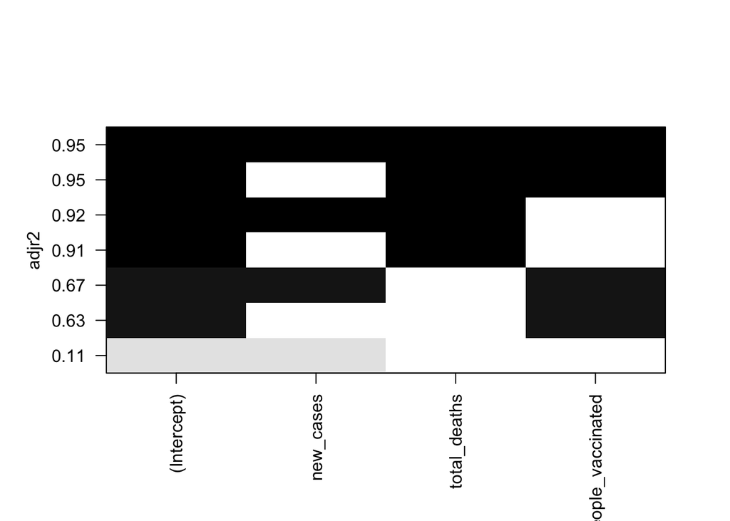

```r
vac_leap <- regsubsets(total_cases_per_million ~ new_cases + total_deaths + people_vaccinated, data = vac_US, nbest = 3)
plot(vac_leap, scale="adjr2")
```

```r
summary(model3)
```

```
##
## Call:
## lm(formula = total_cases ~ new_cases + total_deaths + people_fully_vaccinated,
##     data = vac_US)
##
## Residuals:
##      Min       1Q   Median       3Q      Max
## -8588381 -3138643   365075  1806183  8818978
##
## Coefficients:
##                           Estimate Std. Error t value Pr(>|t|)
## (Intercept)             -3.129e+07  1.010e+06 -30.981  < 2e-16 ***
## new_cases                6.570e+00  1.022e+00   6.429 3.28e-10 ***
## total_deaths             1.280e+02  2.498e+00  51.244  < 2e-16 ***
## people_fully_vaccinated -8.119e-02  5.216e-03 -15.566  < 2e-16 ***
## ---
## Signif. codes:  0 '***' 0.001 '**' 0.01 '*' 0.05 '.' 0.1 ' ' 1
##
## Residual standard error: 3715000 on 451 degrees of freedom
##   (1 observation deleted due to missingness)
## Multiple R-squared:  0.9469, Adjusted R-squared:  0.9465
## F-statistic:  2679 on 3 and 451 DF,  p-value: < 2.2e-16
```

```r
confint(model3, 'people_fully_vaccinated', level=0.99)
```

```
##                               0.5 %      99.5 %
## people_fully_vaccinated -0.09468322 -0.06769801
```

# Sensitivity analysis

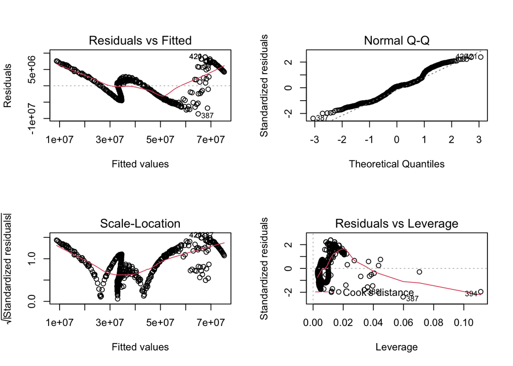

```r
par(mfrow=c(2,2))
plot(model3)
```

In this part, we use four different plots to show our how much uncertainty we have in our modelling.

The first plot is a residuals vs fitted plot. From this plot, we can see that the residuals are not randomly distributed among 0 and it shows some certain patterns. This means that the relation between cumulative cases total number of people who full vaccinated is not exactly linear.

The second plot is called QQ plot. From this plot, we can see that the points at two tails are not fitted to the y=x line. This means our model didn’t build the best relationship between the variables and there might be some errors in our model.

The third plot is the scale-location plot. From this plot, we can see that the points are not randomly scattered around the red line. This means that the assumption of homoscedasticity is not satisfied in the model we construct.

And the last plot is the residual vs leverage plot. From this plot, we can see that no points are located outside the border of Cook’s distance. This means there are not any influential points in our model.

# Conclusion

Then, in the modelling part, we found that there indeed a negative relationship between cumulative infection cases and the total number of people who full vaccinated. This might means that as the total number of people who full vaccinated increase, cumulative infection cases might decrease, which is definitely a good news for us. However，in the diagnosis analysis, we found that there still lots of deficiency in our model. In general, we can say that it is not enough for us to build a linear model between the two variables we want to analyze, because the true relationship between them is definitely much more complicated. Therefore, if in next time, our team has a more knowledge to finish a comprehensive analysis, we will try to construct a more complex model and finish our analysis with a more powerful conclusion.

## Reference

vaccine_information <- https://en.wikipedia.org/wiki/COVID-19_vaccine

vaccine_track <- “https://ourworldindata.org/covid-vaccinations”

Benefits_of_COVID_19_Vaccine <- https://www.cdc.gov/coronavirus/2019-ncov/vaccines/vaccine-benefits.html